# Risk Factor Analysis

## Outcome Variable

**Outcome Variable:** stunted

## Predictor Variables

**Intervention Variable:** exclfeed36

**Adjustment Set:**

- arm
- sex
- brthmon
- W_mage
- meducyrs
- feducyrs
- hhwealth_quart
- hfoodsec
- W_mhtcm
- W_mwtkg
- W_mbmi
- vagbrth
- W_gagebrth
- W_birthwt
- W_birthlen
- W_nrooms
- W_nchldlt5
- month
- W_parity
- impfloor
- impsan
- safeh20
- delta_W_mage
- delta_meducyrs
- delta_feducyrs
- delta_hhwealth_quart
- delta_hfoodsec
- delta_W_mhtcm
- delta_W_mwtkg
- delta_W_mbmi
- delta_vagbrth
- delta_W_gagebrth
- delta_W_birthwt
- delta_W_birthlen
- delta_W_nrooms
- delta_W_nchldlt5
- delta_month
- delta_W_parity
- delta_impfloor
- delta_impsan
- delta_safeh20

## Stratifying Variables

The analysis was stratified on these variable(s):

- agecat
- studyid
- country

## Data Summary

| agecat | studyid | country | exclfeed36 | stunted | n_cell | n |
| --- | --- | --- | --- | --- | --- | --- |
| Birth | CMC-V-BCS-2002 | INDIA | 1 | 0 | 3 | 3 |
| Birth | CMC-V-BCS-2002 | INDIA | 1 | 1 | 0 | 3 |
| Birth | CMC-V-BCS-2002 | INDIA | 0 | 0 | 0 | 3 |
| Birth | CMC-V-BCS-2002 | INDIA | 0 | 1 | 0 | 3 |
| Birth | EE | PAKISTAN | 1 | 0 | 2 | 7 |
| Birth | EE | PAKISTAN | 1 | 1 | 1 | 7 |
| Birth | EE | PAKISTAN | 0 | 0 | 3 | 7 |
| Birth | EE | PAKISTAN | 0 | 1 | 1 | 7 |
| Birth | GMS-Nepal | NEPAL | 1 | 0 | 356 | 526 |
| Birth | GMS-Nepal | NEPAL | 1 | 1 | 66 | 526 |
| Birth | GMS-Nepal | NEPAL | 0 | 0 | 85 | 526 |
| Birth | GMS-Nepal | NEPAL | 0 | 1 | 19 | 526 |
| Birth | IRC | INDIA | 1 | 0 | 0 | 4 |
| Birth | IRC | INDIA | 1 | 1 | 0 | 4 |
| Birth | IRC | INDIA | 0 | 0 | 3 | 4 |
| Birth | IRC | INDIA | 0 | 1 | 1 | 4 |
| Birth | JiVitA-3 | BANGLADESH | 1 | 0 | 5638 | 10681 |
| Birth | JiVitA-3 | BANGLADESH | 1 | 1 | 2684 | 10681 |
| Birth | JiVitA-3 | BANGLADESH | 0 | 0 | 1588 | 10681 |
| Birth | JiVitA-3 | BANGLADESH | 0 | 1 | 771 | 10681 |
| Birth | JiVitA-4 | BANGLADESH | 1 | 0 | 1406 | 2517 |
| Birth | JiVitA-4 | BANGLADESH | 1 | 1 | 588 | 2517 |
| Birth | JiVitA-4 | BANGLADESH | 0 | 0 | 350 | 2517 |
| Birth | JiVitA-4 | BANGLADESH | 0 | 1 | 173 | 2517 |
| Birth | Keneba | GAMBIA | 1 | 0 | 347 | 1253 |
| Birth | Keneba | GAMBIA | 1 | 1 | 16 | 1253 |
| Birth | Keneba | GAMBIA | 0 | 0 | 839 | 1253 |
| Birth | Keneba | GAMBIA | 0 | 1 | 51 | 1253 |
| Birth | MAL-ED | BANGLADESH | 1 | 0 | 28 | 221 |
| Birth | MAL-ED | BANGLADESH | 1 | 1 | 4 | 221 |

[output cut: 162 more lines]

The following strata were considered:

- agecat: 24 months, studyid: CMC-V-BCS-2002, country: INDIA
- agecat: 24 months, studyid: EE, country: PAKISTAN
- agecat: 24 months, studyid: GMS-Nepal, country: NEPAL
- agecat: 24 months, studyid: IRC, country: INDIA
- agecat: 24 months, studyid: JiVitA-3, country: BANGLADESH
- agecat: 24 months, studyid: JiVitA-4, country: BANGLADESH
- agecat: 24 months, studyid: Keneba, country: GAMBIA
- agecat: 24 months, studyid: LCNI-5, country: MALAWI
- agecat: 24 months, studyid: MAL-ED, country: BANGLADESH
- agecat: 24 months, studyid: MAL-ED, country: BRAZIL
- agecat: 24 months, studyid: MAL-ED, country: INDIA
- agecat: 24 months, studyid: MAL-ED, country: NEPAL
- agecat: 24 months, studyid: MAL-ED, country: PERU
- agecat: 24 months, studyid: MAL-ED, country: SOUTH AFRICA
- agecat: 24 months, studyid: MAL-ED, country: TANZANIA, UNITED REPUBLIC OF
- agecat: 24 months, studyid: PROVIDE, country: BANGLADESH
- agecat: 6 months, studyid: CMC-V-BCS-2002, country: INDIA
- agecat: 6 months, studyid: EE, country: PAKISTAN
- agecat: 6 months, studyid: GMS-Nepal, country: NEPAL
- agecat: 6 months, studyid: IRC, country: INDIA
- agecat: 6 months, studyid: JiVitA-3, country: BANGLADESH
- agecat: 6 months, studyid: JiVitA-4, country: BANGLADESH
- agecat: 6 months, studyid: Keneba, country: GAMBIA
- agecat: 6 months, studyid: LCNI-5, country: MALAWI
- agecat: 6 months, studyid: MAL-ED, country: BANGLADESH
- agecat: 6 months, studyid: MAL-ED, country: BRAZIL
- agecat: 6 months, studyid: MAL-ED, country: INDIA
- agecat: 6 months, studyid: MAL-ED, country: NEPAL
- agecat: 6 months, studyid: MAL-ED, country: PERU
- agecat: 6 months, studyid: MAL-ED, country: SOUTH AFRICA
- agecat: 6 months, studyid: MAL-ED, country: TANZANIA, UNITED REPUBLIC OF
- agecat: 6 months, studyid: PROVIDE, country: BANGLADESH
- agecat: 6 months, studyid: SAS-FoodSuppl, country: INDIA
- agecat: Birth, studyid: CMC-V-BCS-2002, country: INDIA
- agecat: Birth, studyid: EE, country: PAKISTAN
- agecat: Birth, studyid: GMS-Nepal, country: NEPAL
- agecat: Birth, studyid: IRC, country: INDIA
- agecat: Birth, studyid: JiVitA-3, country: BANGLADESH
- agecat: Birth, studyid: JiVitA-4, country: BANGLADESH
- agecat: Birth, studyid: Keneba, country: GAMBIA
- agecat: Birth, studyid: MAL-ED, country: BANGLADESH
- agecat: Birth, studyid: MAL-ED, country: BRAZIL
- agecat: Birth, studyid: MAL-ED, country: INDIA
- agecat: Birth, studyid: MAL-ED, country: NEPAL
- agecat: Birth, studyid: MAL-ED, country: PERU
- agecat: Birth, studyid: MAL-ED, country: SOUTH AFRICA
- agecat: Birth, studyid: MAL-ED, country: TANZANIA, UNITED REPUBLIC OF
- agecat: Birth, studyid: PROVIDE, country: BANGLADESH

### Dropped Strata

Some strata were dropped due to rare outcomes:

- agecat: Birth, studyid: CMC-V-BCS-2002, country: INDIA
- agecat: Birth, studyid: EE, country: PAKISTAN
- agecat: Birth, studyid: IRC, country: INDIA
- agecat: Birth, studyid: MAL-ED, country: BANGLADESH
- agecat: Birth, studyid: MAL-ED, country: BRAZIL
- agecat: Birth, studyid: MAL-ED, country: INDIA
- agecat: Birth, studyid: MAL-ED, country: NEPAL
- agecat: Birth, studyid: MAL-ED, country: PERU
- agecat: Birth, studyid: MAL-ED, country: SOUTH AFRICA
- agecat: Birth, studyid: MAL-ED, country: TANZANIA, UNITED REPUBLIC OF
- agecat: 6 months, studyid: CMC-V-BCS-2002, country: INDIA
- agecat: 6 months, studyid: EE, country: PAKISTAN
- agecat: 6 months, studyid: IRC, country: INDIA
- agecat: 6 months, studyid: MAL-ED, country: BRAZIL
- agecat: 6 months, studyid: MAL-ED, country: INDIA
- agecat: 6 months, studyid: MAL-ED, country: NEPAL
- agecat: 6 months, studyid: MAL-ED, country: PERU
- agecat: 6 months, studyid: MAL-ED, country: SOUTH AFRICA
- agecat: 6 months, studyid: MAL-ED, country: TANZANIA, UNITED REPUBLIC OF
- agecat: 6 months, studyid: SAS-FoodSuppl, country: INDIA
- agecat: 24 months, studyid: CMC-V-BCS-2002, country: INDIA
- agecat: 24 months, studyid: EE, country: PAKISTAN
- agecat: 24 months, studyid: IRC, country: INDIA
- agecat: 24 months, studyid: MAL-ED, country: BRAZIL
- agecat: 24 months, studyid: MAL-ED, country: INDIA
- agecat: 24 months, studyid: MAL-ED, country: NEPAL
- agecat: 24 months, studyid: MAL-ED, country: PERU
- agecat: 24 months, studyid: MAL-ED, country: SOUTH AFRICA
- agecat: 24 months, studyid: MAL-ED, country: TANZANIA, UNITED REPUBLIC OF

## Methods Detail

We’re interested in the causal parameters $E[Y_a]$ for all values of $a \in \mathcal{A}$. These parameters represent the mean outcome if, possibly contrary to fact, we intervened to set all units to have $A=a$. Under the randomization and positivity assumptions, these are identified by the statistical parameters $\psi_a=E_W[E_{Y|A,W}(Y|A=a,W)]$. In addition, we’re interested in the mean of $Y$, $E[Y]$ under no intervention (the observed mean). We will estimate these parameters by using SuperLearner to fit the relevant likelihood factors – $E_{Y|A,W}(Y|A=a,W)$ and $p(A=a|W)$, and then updating our likelihood fit using a joint TMLE.

For unadjusted analyses ($W=\{\}$), initial likelihoods were estimated using Lrnr_glm to estimate the simple $E(Y|A)$ and Lrnr_mean to estimate $p(A)$. For adjusted analyses, a small library containing Lrnr_glmnet, Lrnr_xgboost, and Lrnr_mean was used.

Having estimated these parameters, we will then use the delta method to estimate relative risks and attributable risks relative to a prespecified baseline level of $A$.

# Results Detail

## Results Plots

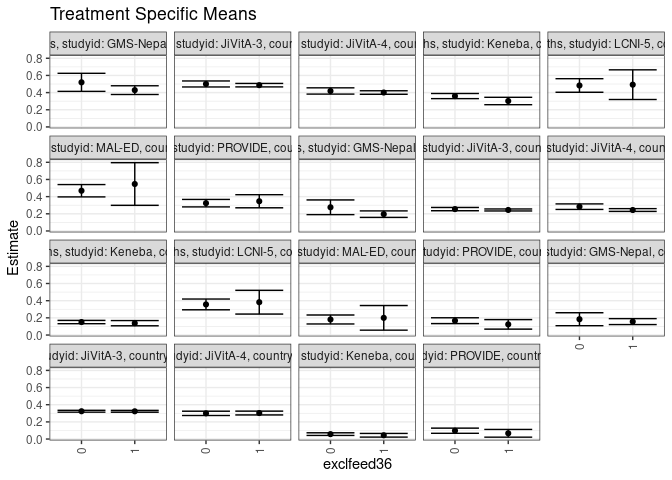

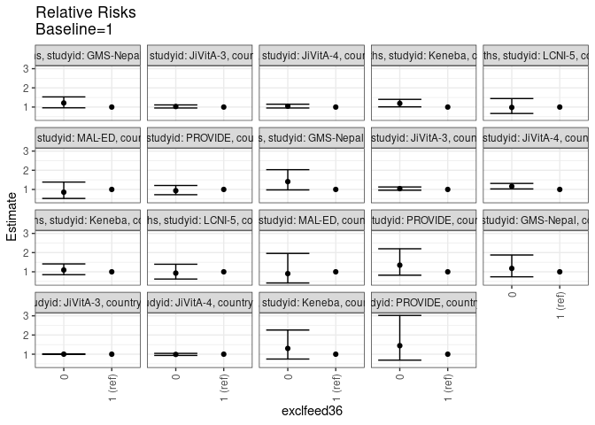

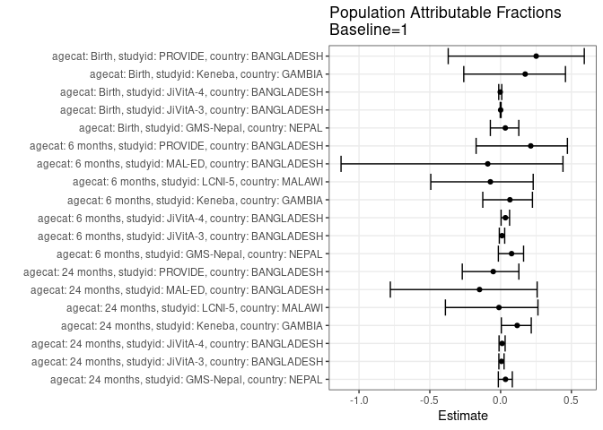

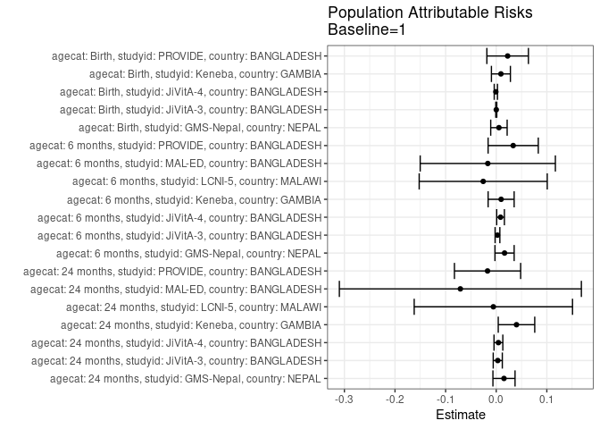

## Results Table

### Parameter: TSM

| agecat | studyid | country | intervention_level | baseline_level | estimate | ci_lower | ci_upper |
| --- | --- | --- | --- | --- | --- | --- | --- |
| Birth | GMS-Nepal | NEPAL | 1 | NA | 0.1562334 | 0.1215665 | 0.1909002 |
| Birth | GMS-Nepal | NEPAL | 0 | NA | 0.1840102 | 0.1085191 | 0.2595013 |
| Birth | JiVitA-3 | BANGLADESH | 1 | NA | 0.3233557 | 0.3129636 | 0.3337478 |
| Birth | JiVitA-3 | BANGLADESH | 0 | NA | 0.3239711 | 0.3130725 | 0.3348696 |
| Birth | JiVitA-4 | BANGLADESH | 1 | NA | 0.3030659 | 0.2809453 | 0.3251866 |
| Birth | JiVitA-4 | BANGLADESH | 0 | NA | 0.2994661 | 0.2744982 | 0.3244340 |
| Birth | Keneba | GAMBIA | 1 | NA | 0.0441890 | 0.0228286 | 0.0655494 |
| Birth | Keneba | GAMBIA | 0 | NA | 0.0574508 | 0.0420901 | 0.0728116 |
| Birth | PROVIDE | BANGLADESH | 1 | NA | 0.0672269 | 0.0221890 | 0.1122648 |
| Birth | PROVIDE | BANGLADESH | 0 | NA | 0.0970350 | 0.0668838 | 0.1271862 |
| 6 months | GMS-Nepal | NEPAL | 1 | NA | 0.1960536 | 0.1579921 | 0.2341150 |
| 6 months | GMS-Nepal | NEPAL | 0 | NA | 0.2759704 | 0.1904083 | 0.3615324 |
| 6 months | JiVitA-3 | BANGLADESH | 1 | NA | 0.2447171 | 0.2332299 | 0.2562042 |
| 6 months | JiVitA-3 | BANGLADESH | 0 | NA | 0.2549047 | 0.2358627 | 0.2739468 |
| 6 months | JiVitA-4 | BANGLADESH | 1 | NA | 0.2440232 | 0.2278999 | 0.2601466 |
| 6 months | JiVitA-4 | BANGLADESH | 0 | NA | 0.2832185 | 0.2507823 | 0.3156547 |
| 6 months | Keneba | GAMBIA | 1 | NA | 0.1377759 | 0.1074178 | 0.1681340 |
| 6 months | Keneba | GAMBIA | 0 | NA | 0.1509297 | 0.1315505 | 0.1703090 |
| 6 months | LCNI-5 | MALAWI | 1 | NA | 0.3823347 | 0.2441190 | 0.5205504 |
| 6 months | LCNI-5 | MALAWI | 0 | NA | 0.3563528 | 0.2937024 | 0.4190032 |
| 6 months | MAL-ED | BANGLADESH | 1 | NA | 0.2000000 | 0.0565653 | 0.3434347 |
| 6 months | MAL-ED | BANGLADESH | 0 | NA | 0.1809524 | 0.1287751 | 0.2331297 |
| 6 months | PROVIDE | BANGLADESH | 1 | NA | 0.1240072 | 0.0685368 | 0.1794776 |
| 6 months | PROVIDE | BANGLADESH | 0 | NA | 0.1670001 | 0.1328997 | 0.2011006 |
| 24 months | GMS-Nepal | NEPAL | 1 | NA | 0.4285968 | 0.3777641 | 0.4794295 |
| 24 months | GMS-Nepal | NEPAL | 0 | NA | 0.5197009 | 0.4144208 | 0.6249811 |
| 24 months | JiVitA-3 | BANGLADESH | 1 | NA | 0.4865510 | 0.4664346 | 0.5066673 |
| 24 months | JiVitA-3 | BANGLADESH | 0 | NA | 0.5004617 | 0.4654450 | 0.5354784 |
| 24 months | JiVitA-4 | BANGLADESH | 1 | NA | 0.4009351 | 0.3807150 | 0.4211552 |
| 24 months | JiVitA-4 | BANGLADESH | 0 | NA | 0.4189006 | 0.3823991 | 0.4554022 |
| 24 months | Keneba | GAMBIA | 1 | NA | 0.3021135 | 0.2590208 | 0.3452061 |
| 24 months | Keneba | GAMBIA | 0 | NA | 0.3595197 | 0.3296887 | 0.3893508 |
| 24 months | LCNI-5 | MALAWI | 1 | NA | 0.4924246 | 0.3198172 | 0.6650320 |
| 24 months | LCNI-5 | MALAWI | 0 | NA | 0.4830086 | 0.4039898 | 0.5620275 |
| 24 months | MAL-ED | BANGLADESH | 1 | NA | 0.5472572 | 0.2985931 | 0.7959212 |
| 24 months | MAL-ED | BANGLADESH | 0 | NA | 0.4688129 | 0.3967880 | 0.5408379 |
| 24 months | PROVIDE | BANGLADESH | 1 | NA | 0.3464369 | 0.2700907 | 0.4227831 |
| 24 months | PROVIDE | BANGLADESH | 0 | NA | 0.3239897 | 0.2803949 | 0.3675845 |

### Parameter: E(Y)

| agecat | studyid | country | intervention_level | baseline_level | estimate | ci_lower | ci_upper |
| --- | --- | --- | --- | --- | --- | --- | --- |
| Birth | GMS-Nepal | NEPAL | NA | NA | 0.1615970 | 0.1301114 | 0.1930825 |
| Birth | JiVitA-3 | BANGLADESH | NA | NA | 0.3234716 | 0.3131402 | 0.3338029 |
| Birth | JiVitA-4 | BANGLADESH | NA | NA | 0.3023441 | 0.2806174 | 0.3240708 |
| Birth | Keneba | GAMBIA | NA | NA | 0.0534717 | 0.0410100 | 0.0659333 |
| Birth | PROVIDE | BANGLADESH | NA | NA | 0.0897959 | 0.0644568 | 0.1151350 |
| 6 months | GMS-Nepal | NEPAL | NA | NA | 0.2125237 | 0.1775632 | 0.2474842 |
| 6 months | JiVitA-3 | BANGLADESH | NA | NA | 0.2471936 | 0.2366536 | 0.2577336 |
| 6 months | JiVitA-4 | BANGLADESH | NA | NA | 0.2525687 | 0.2374550 | 0.2676823 |
| 6 months | Keneba | GAMBIA | NA | NA | 0.1474860 | 0.1310548 | 0.1639172 |
| 6 months | LCNI-5 | MALAWI | NA | NA | 0.3566176 | 0.2995882 | 0.4136471 |
| 6 months | MAL-ED | BANGLADESH | NA | NA | 0.1833333 | 0.1342773 | 0.2323893 |
| 6 months | PROVIDE | BANGLADESH | NA | NA | 0.1575456 | 0.1284434 | 0.1866478 |
| 24 months | GMS-Nepal | NEPAL | NA | NA | 0.4439462 | 0.3977834 | 0.4901089 |
| 24 months | JiVitA-3 | BANGLADESH | NA | NA | 0.4896170 | 0.4715168 | 0.5077172 |
| 24 months | JiVitA-4 | BANGLADESH | NA | NA | 0.4052853 | 0.3865623 | 0.4240082 |
| 24 months | Keneba | GAMBIA | NA | NA | 0.3421808 | 0.3172662 | 0.3670954 |
| 24 months | LCNI-5 | MALAWI | NA | NA | 0.4867725 | 0.4153250 | 0.5582200 |
| 24 months | MAL-ED | BANGLADESH | NA | NA | 0.4764151 | 0.4090254 | 0.5438047 |
| 24 months | PROVIDE | BANGLADESH | NA | NA | 0.3292894 | 0.2909105 | 0.3676684 |

### Parameter: RR

| agecat | studyid | country | intervention_level | baseline_level | estimate | ci_lower | ci_upper |
| --- | --- | --- | --- | --- | --- | --- | --- |
| Birth | GMS-Nepal | NEPAL | 1 | 1 | 1.0000000 | 1.0000000 | 1.000000 |
| Birth | GMS-Nepal | NEPAL | 0 | 1 | 1.1777907 | 0.7391156 | 1.876825 |
| Birth | JiVitA-3 | BANGLADESH | 1 | 1 | 1.0000000 | 1.0000000 | 1.000000 |
| Birth | JiVitA-3 | BANGLADESH | 0 | 1 | 1.0019032 | 0.9879740 | 1.016029 |
| Birth | JiVitA-4 | BANGLADESH | 1 | 1 | 1.0000000 | 1.0000000 | 1.000000 |
| Birth | JiVitA-4 | BANGLADESH | 0 | 1 | 0.9881220 | 0.9354730 | 1.043734 |
| Birth | Keneba | GAMBIA | 1 | 1 | 1.0000000 | 1.0000000 | 1.000000 |
| Birth | Keneba | GAMBIA | 0 | 1 | 1.3001158 | 0.7479904 | 2.259790 |
| Birth | PROVIDE | BANGLADESH | 1 | 1 | 1.0000000 | 1.0000000 | 1.000000 |
| Birth | PROVIDE | BANGLADESH | 0 | 1 | 1.4433962 | 0.6897053 | 3.020700 |
| 6 months | GMS-Nepal | NEPAL | 1 | 1 | 1.0000000 | 1.0000000 | 1.000000 |
| 6 months | GMS-Nepal | NEPAL | 0 | 1 | 1.4076273 | 0.9759234 | 2.030297 |
| 6 months | JiVitA-3 | BANGLADESH | 1 | 1 | 1.0000000 | 1.0000000 | 1.000000 |
| 6 months | JiVitA-3 | BANGLADESH | 0 | 1 | 1.0416304 | 0.9608074 | 1.129252 |
| 6 months | JiVitA-4 | BANGLADESH | 1 | 1 | 1.0000000 | 1.0000000 | 1.000000 |
| 6 months | JiVitA-4 | BANGLADESH | 0 | 1 | 1.1606209 | 1.0249947 | 1.314193 |
| 6 months | Keneba | GAMBIA | 1 | 1 | 1.0000000 | 1.0000000 | 1.000000 |
| 6 months | Keneba | GAMBIA | 0 | 1 | 1.0954728 | 0.8501616 | 1.411568 |
| 6 months | LCNI-5 | MALAWI | 1 | 1 | 1.0000000 | 1.0000000 | 1.000000 |
| 6 months | LCNI-5 | MALAWI | 0 | 1 | 0.9320443 | 0.6226054 | 1.395276 |
| 6 months | MAL-ED | BANGLADESH | 1 | 1 | 1.0000000 | 1.0000000 | 1.000000 |
| 6 months | MAL-ED | BANGLADESH | 0 | 1 | 0.9047619 | 0.4176743 | 1.959886 |
| 6 months | PROVIDE | BANGLADESH | 1 | 1 | 1.0000000 | 1.0000000 | 1.000000 |
| 6 months | PROVIDE | BANGLADESH | 0 | 1 | 1.3466974 | 0.8237312 | 2.201682 |
| 24 months | GMS-Nepal | NEPAL | 1 | 1 | 1.0000000 | 1.0000000 | 1.000000 |
| 24 months | GMS-Nepal | NEPAL | 0 | 1 | 1.2125637 | 0.9606003 | 1.530617 |
| 24 months | JiVitA-3 | BANGLADESH | 1 | 1 | 1.0000000 | 1.0000000 | 1.000000 |
| 24 months | JiVitA-3 | BANGLADESH | 0 | 1 | 1.0285905 | 0.9515593 | 1.111858 |
| 24 months | JiVitA-4 | BANGLADESH | 1 | 1 | 1.0000000 | 1.0000000 | 1.000000 |
| 24 months | JiVitA-4 | BANGLADESH | 0 | 1 | 1.0448091 | 0.9513935 | 1.147397 |
| 24 months | Keneba | GAMBIA | 1 | 1 | 1.0000000 | 1.0000000 | 1.000000 |
| 24 months | Keneba | GAMBIA | 0 | 1 | 1.1900156 | 1.0111554 | 1.400514 |
| 24 months | LCNI-5 | MALAWI | 1 | 1 | 1.0000000 | 1.0000000 | 1.000000 |
| 24 months | LCNI-5 | MALAWI | 0 | 1 | 0.9808784 | 0.6663782 | 1.443808 |
| 24 months | MAL-ED | BANGLADESH | 1 | 1 | 1.0000000 | 1.0000000 | 1.000000 |
| 24 months | MAL-ED | BANGLADESH | 0 | 1 | 0.8566593 | 0.5303555 | 1.383723 |
| 24 months | PROVIDE | BANGLADESH | 1 | 1 | 1.0000000 | 1.0000000 | 1.000000 |
| 24 months | PROVIDE | BANGLADESH | 0 | 1 | 0.9352056 | 0.7256709 | 1.205243 |

### Parameter: PAR

| agecat | studyid | country | intervention_level | baseline_level | estimate | ci_lower | ci_upper |
| --- | --- | --- | --- | --- | --- | --- | --- |
| Birth | GMS-Nepal | NEPAL | 1 | NA | 0.0053636 | -0.0108581 | 0.0215853 |
| Birth | JiVitA-3 | BANGLADESH | 1 | NA | 0.0001159 | -0.0008875 | 0.0011194 |
| Birth | JiVitA-4 | BANGLADESH | 1 | NA | -0.0007219 | -0.0039535 | 0.0025097 |
| Birth | Keneba | GAMBIA | 1 | NA | 0.0092827 | -0.0094692 | 0.0280345 |
| Birth | PROVIDE | BANGLADESH | 1 | NA | 0.0225690 | -0.0184828 | 0.0636209 |
| 6 months | GMS-Nepal | NEPAL | 1 | NA | 0.0164701 | -0.0025054 | 0.0354457 |
| 6 months | JiVitA-3 | BANGLADESH | 1 | NA | 0.0024766 | -0.0022287 | 0.0071818 |
| 6 months | JiVitA-4 | BANGLADESH | 1 | NA | 0.0085455 | 0.0009356 | 0.0161553 |
| 6 months | Keneba | GAMBIA | 1 | NA | 0.0097101 | -0.0160004 | 0.0354207 |
| 6 months | LCNI-5 | MALAWI | 1 | NA | -0.0257170 | -0.1522386 | 0.1008046 |
| 6 months | MAL-ED | BANGLADESH | 1 | NA | -0.0166667 | -0.1502205 | 0.1168871 |
| 6 months | PROVIDE | BANGLADESH | 1 | NA | 0.0335384 | -0.0160304 | 0.0831073 |
| 24 months | GMS-Nepal | NEPAL | 1 | NA | 0.0153494 | -0.0065068 | 0.0372055 |
| 24 months | JiVitA-3 | BANGLADESH | 1 | NA | 0.0030660 | -0.0059196 | 0.0120516 |
| 24 months | JiVitA-4 | BANGLADESH | 1 | NA | 0.0043502 | -0.0043549 | 0.0130552 |
| 24 months | Keneba | GAMBIA | 1 | NA | 0.0400673 | 0.0040189 | 0.0761157 |
| 24 months | LCNI-5 | MALAWI | 1 | NA | -0.0056521 | -0.1620794 | 0.1507752 |
| 24 months | MAL-ED | BANGLADESH | 1 | NA | -0.0708421 | -0.3099664 | 0.1682822 |
| 24 months | PROVIDE | BANGLADESH | 1 | NA | -0.0171475 | -0.0825700 | 0.0482751 |

### Parameter: PAF

| agecat | studyid | country | intervention_level | baseline_level | estimate | ci_lower | ci_upper |
| --- | --- | --- | --- | --- | --- | --- | --- |
| Birth | GMS-Nepal | NEPAL | 1 | NA | 0.0331912 | -0.0724502 | 0.1284264 |
| Birth | JiVitA-3 | BANGLADESH | 1 | NA | 0.0003584 | -0.0027487 | 0.0034559 |
| Birth | JiVitA-4 | BANGLADESH | 1 | NA | -0.0023876 | -0.0131262 | 0.0082371 |
| Birth | Keneba | GAMBIA | 1 | NA | 0.1735994 | -0.2600991 | 0.4580284 |
| Birth | PROVIDE | BANGLADESH | 1 | NA | 0.2513369 | -0.3701009 | 0.5909086 |
| 6 months | GMS-Nepal | NEPAL | 1 | NA | 0.0774979 | -0.0158400 | 0.1622597 |
| 6 months | JiVitA-3 | BANGLADESH | 1 | NA | 0.0100187 | -0.0091994 | 0.0288710 |
| 6 months | JiVitA-4 | BANGLADESH | 1 | NA | 0.0338342 | 0.0033995 | 0.0633395 |
| 6 months | Keneba | GAMBIA | 1 | NA | 0.0658377 | -0.1259014 | 0.2249239 |
| 6 months | LCNI-5 | MALAWI | 1 | NA | -0.0721137 | -0.4930813 | 0.2301639 |
| 6 months | MAL-ED | BANGLADESH | 1 | NA | -0.0909091 | -1.1267403 | 0.4404194 |
| 6 months | PROVIDE | BANGLADESH | 1 | NA | 0.2128809 | -0.1729710 | 0.4718058 |
| 24 months | GMS-Nepal | NEPAL | 1 | NA | 0.0345749 | -0.0160252 | 0.0826550 |
| 24 months | JiVitA-3 | BANGLADESH | 1 | NA | 0.0062621 | -0.0122596 | 0.0244448 |
| 24 months | JiVitA-4 | BANGLADESH | 1 | NA | 0.0107336 | -0.0109589 | 0.0319606 |
| 24 months | Keneba | GAMBIA | 1 | NA | 0.1170939 | 0.0051517 | 0.2164403 |
| 24 months | LCNI-5 | MALAWI | 1 | NA | -0.0116114 | -0.3898557 | 0.2636951 |
| 24 months | MAL-ED | BANGLADESH | 1 | NA | -0.1486982 | -0.7787302 | 0.2581744 |
| 24 months | PROVIDE | BANGLADESH | 1 | NA | -0.0520741 | -0.2707520 | 0.1289725 |